# Homework 12

Yu-Jen Lin

#### b04b01036@ntu.edu.tw

#### ——————————————————————————————————————————————————–

#### 1. Please estimate the model parameters of four different growth functions (von Bertalanffy; Gompertz; Logis>c; Schnute–Richards) using the method maximum likelihood for the length-at-age for female Pacific hake (Merluccius productus) considering a log-normal distribution

## Models

#### 1 von Bertalanffy Growth Function

#### -> L(t) = L∞ (1−exp(−k(t−t0)))

#### 2 Gompertz growth model

#### -> L(t) = L∞ exp(-exp(-k2(t-((ln(λ)-ln(k2))/k2 ))))

#### 3 Logistic model

#### -> L(t) = L∞ (1 + exp(-k3(t-t3)))^(-1)

#### 4 Schnute–Richards model] Bonus

#### -> L(t) = L∞ exp(1 + δ*e^(-k4 t^v)) ^ (1/γ)

## Considering a log-normal distribution

#### L(t) = Model * e^ε , ε ~ N(0,σ^2)

## loading package and data

```r
library(knitr)
library(ggplot2)

Age = c(1,2,3.3,4.3,5.3,6.3,7.3,8.3,9.3,10.3,11.3,12.3,13.3)
Length = c(15.4,28.03,41.18,46.2,48.23,50.26,51.82,54.27,56.98,58.93,59,60.91,61.83)

data = cbind(Age, Length)

kable(data, col.names = c("Age (year)", "Female mean length (cm)"))
```

| Age (year) | Female mean length (cm) |
| --- | --- |
| 1.0 | 15.40 |
| 2.0 | 28.03 |
| 3.3 | 41.18 |
| 4.3 | 46.20 |
| 5.3 | 48.23 |
| 6.3 | 50.26 |
| 7.3 | 51.82 |
| 8.3 | 54.27 |
| 9.3 | 56.98 |
| 10.3 | 58.93 |
| 11.3 | 59.00 |
| 12.3 | 60.91 |
| 13.3 | 61.83 |

## Check the plot of [ Length ~ Age ]

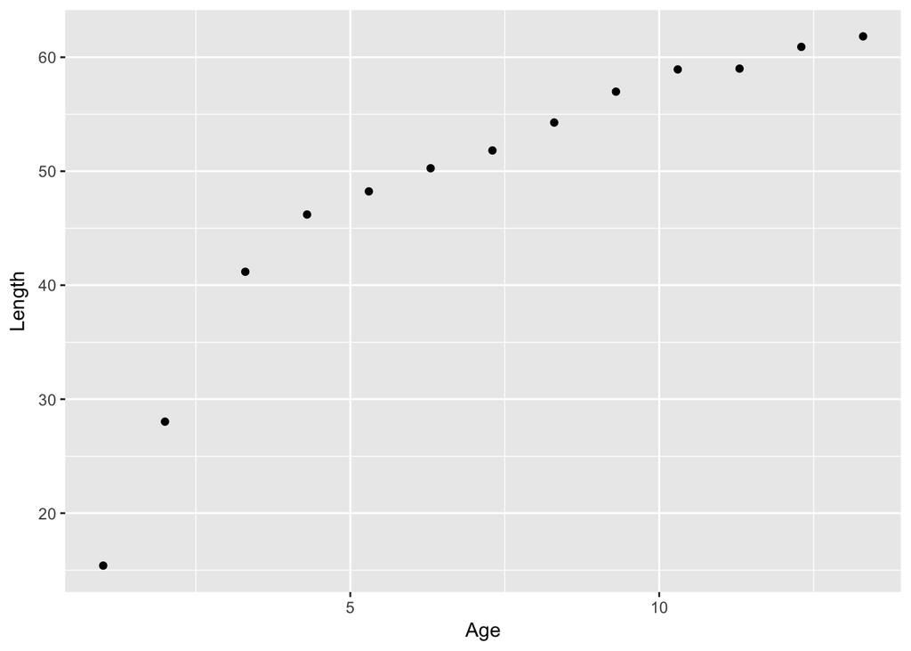

```r
dataset = data.frame(Age, Length) # combine the data
colnames(dataset) <- c("Age", "Length") # rename the columns for plotting
ggplot(dataset, aes(x = Age, y = Length)) +
    geom_point()
```

## 1 von Bertalanffy Growth Function

#### L(t) = L∞ (1−exp(−k(t−t0)))

#### L∞ = Linf = hypothesized (mean) maximum length

#### k = growth rate

#### t = x = current age

#### t0 = hypothesized age when body length is 0

```r
VBGF <- function(x, Linf = theta[1], k = theta[2], t0 = theta[3], theta = c(Linf, k, t0)){
    y = Linf * (1 - exp(-k * (x - t0)))
    return(y)
}
```

## 2 Gompertz growth model

#### L(t) = L∞ exp(-exp(-k2(t-((ln(λ)-ln(k2))/k2 ))))

#### L∞ = Linf = hypothesized (mean) maximum length

#### k2 = (k) = rate of exponential decrease of the relative growth rate with age

#### t = x = current age

#### λ = (t0) = theoretical initial relative growth rate at zero age

#### (I change some annotations in order to calculate in an easier way.)

```r
GGM <- function(x, Linf = theta[1], k = theta[2], t0 = theta[3], theta = c(Linf, k, t0)){
    y = Linf * exp(- exp(- k * (x - (log(t0) - log(k)) / k)))
    return(y)
}
```

## 3 Logistic model

#### L(t) = L∞ (1 + exp(-k3(t-t3)))^(-1)

#### L∞ = Linf = hypothesized (mean) maximum length

#### k3 = (k) = relative growth rate parameter (with units year^-1)

#### t = x = current age

#### t3 = (t0) = corresponds to the inflection point of the sigmoidal curve

#### (I change some annotations in order to calculate in an easier way.)

```r
LM <- function(x, Linf = theta[1], k = theta[2], t0 = theta[3], theta = c(Linf, k, t0)){
    y = Linf * (1 + exp(-k*(x-t0))) ^ (-1)
    return(y)
}
```

## 4 Schnute–Richards model (Bonus)

```r
e <- exp(1)
SRM <- function(x, Linf = theta[1], k = theta[2], δ = theta[3], v = theta[4], γ = theta[5], theta = c(Linf, k, δ, v, γ)){
    y = Linf * exp(1 + δ* (e^(-k*(x^v)))) ^ (1/γ)
    return(y)
}
```

## Log-likelihood function

```r
lognormal_like = function(x, y, FUN, Out, ...){

    FUN = match.fun(FUN)
    Like = numeric(length(y))
    NLL = numeric(length(y))
    ypred = FUN(x, ...)
    Dev2 = (log(Length/ypred)) ^ 2
    sigma = sqrt(mean(Dev2))

    for (i in 1:length(Age)){
        Like[i] = (1 / (x[i] * sqrt(2 * pi) * sigma)) * exp(-Dev2[i] / (2 * sigma ^ 2))
        NLL[i] = -log(Like[i])
    }

    if(Out==T) cat(sum(NLL),Linf,K,t0,"\n")

        Outs <- NULL
        Outs$Pred <- ypred
        Outs$Length <- Length
        Outs$Dev2 <- Dev2
        Outs$sigma <- sigma
        Outs$Like <- Like
        Outs$NLL <- NLL
        Outs$Obj <- sum(NLL)

    return(Outs)
}

lognormal_like.SRM = function(x, y, FUN, Out, ...){

    FUN = match.fun(FUN)
    Like = numeric(length(y))
    NLL = numeric(length(y))
    ypred = FUN(x, ...)
    Dev2 = (log(Length/ypred)) ^ 2
    sigma = sqrt(mean(Dev2))

    for (i in 1:length(Age)){
        Like[i] = (1 / (x[i] * sqrt(2 * pi) * sigma)) * exp(-Dev2[i] / (2 * sigma ^ 2))
        NLL[i] = -log(Like[i])
    }

    if(Out==T) cat(sum(NLL),Linf,K,δ,v,γ,"\n")

        Outs <- NULL
        Outs$Pred <- ypred
        Outs$Length <- Length
        Outs$Dev2 <- Dev2
        Outs$sigma <- sigma
        Outs$Like <- Like
        Outs$NLL <- NLL
        Outs$Obj <- sum(NLL)

    return(Outs)
}
```

## Objective function

```r
obj_function = function(theda, ...){
    Outs <- lognormal_like(theda[1], theda[2], theda[3], ...)
    obj <- Outs$Obj
    return(obj)
}
obj_function.SRM = function(theda, ...){
    Outs <- lognormal_like.SRM(theda[1], theda[2], theda[3], theda[4], theda[5],...)
    obj <- Outs$Obj
    return(obj)
}
```

## MLE of parameters

```r
model_VBGF = optim(c(60, 0.7, 0), obj_function, FUN = VBGF, x = Age, y = Length, Out = F, hessian = T)
model_GGM = optim(c(70, 0.6, 0), obj_function, FUN = GGM, x = Age, y = Length, Out = F, hessian = T)
model_LM = optim(c(59, 0.7, 0), obj_function, FUN = LM, x = Age, y = Length, Out = F, hessian = T)
model_SRM = optim(c(61, 0.7, 0, 0, 0.5), obj_function.SRM, FUN = SRM, x = Age, y = Length, Out = F, hessian = T)
```

## Results

```r
param_VBGF <- model_VBGF$par
param_GGM <- model_GGM$par
param_LM <- model_LM$par
param_SRM <- model_SRM$par

sd_VBGF <- sqrt(diag(solve(model_VBGF$hessian)))
sd_GGM <- sqrt(diag(solve(model_GGM$hessian)))
sd_LM <- sqrt(diag(solve(model_LM$hessian)))
sd_SRM <- sqrt(diag(solve(model_SRM$hessian)))

model_result_VBGF <- cbind(param_VBGF, sd_VBGF)
model_result_GGM <- cbind(param_GGM, sd_GGM)
model_result_LM <- cbind(param_LM, sd_LM)
model_result_SRM <- cbind(param_SRM, sd_SRM)

rownames(model_result_VBGF) <- c("L inf", "k", "t0")
rownames(model_result_GGM) <- c("L inf", "k2", "λ")
rownames(model_result_LM) <- c("L inf", "k3", "t3")
rownames(model_result_SRM) <- c("L inf", "K4", "δ", "v", "γ" )

kable(model_result_VBGF, col.names = c("Estimated parameters", "Standard deviation"), caption = "1 von Bertalanffy growth function", digits = 3)
```

1 von Bertalanffy growth function

|  | Estimated parameters | Standard deviation |
| --- | --- | --- |
| L inf | 60.271 | 1.022 |
| k | 0.327 | 0.022 |
| t0 | 0.092 | 0.066 |

```r
kable(model_result_GGM, col.names = c("Estimated parameters", "Standard deviation"), caption = "2 Gompertz growth model", digits = 3)
```

2 Gompertz growth model

|  | Estimated parameters | Standard deviation |
| --- | --- | --- |
| L inf | 58.173 | 1.141 |
| k2 | 0.520 | 0.044 |
| λ | 1.137 | 0.158 |

```r
kable(model_result_LM, col.names = c("Estimated parameters", "Standard deviation"), caption = "3 Logistic model", digits = 3)
```

3 Logistic model

|  | Estimated parameters | Standard deviation |
| --- | --- | --- |
| L inf | 57.015 | 1.319 |
| k3 | 0.753 | 0.084 |
| t3 | 2.226 | 0.135 |

```r
kable(model_result_SRM, col.names = c("Estimated parameters", "Standard deviation"), caption = "4 Schnute–Richards model", digits = 3)
```

4 Schnute–Richards model

|  | Estimated parameters | Standard deviation |
| --- | --- | --- |
| L inf | 51.301 | 48.087 |
| K4 | -4.585 | 1.649 |
| δ | -0.031 | 0.001 |
| v | -0.147 | 0.048 |
| γ | 1.652 | 2.792 |

#### ——————————————————————————————————————————————————–

#### 2. Calculate the 95% confidence intervals for Linf (Professor said we don’t need to do this on each parameter) of the growth functions by using the likelihood profile method

## Negative log-likelihood

```r
VBGF_like = lognormal_like(data[, 1], data[, 2], VBGF, theta = param_VBGF, Out = F)$Obj
GGM_like = lognormal_like(data[, 1], data[, 2], GGM, theta = param_GGM, Out = F)$Obj
LM_like = lognormal_like(data[, 1], data[, 2], LM, theta = param_LM, Out = F)$Obj
SRM_like = lognormal_like(data[, 1], data[, 2], SRM, theta = param_SRM, Out = F)$Obj
```

## 1 VBGF [ L∞ - 95% confidence interval ]

```r
obj_fun = function(theta, ...){
    Outs <- lognormal_like(k = theta[1], t0 = theta[2], ...)
    obj <- Outs$Obj
    return(obj)
}

LVBGF_like = numeric()
LVBGF_range = seq(from = param_VBGF[1] - 40, to = param_VBGF[1] + 100, length.out = 100)
for(i in 1:100){
        LVBGF_est = optim(param_VBGF[c(2, 3)], obj_fun, FUN = VBGF, Linf = LVBGF_range[i], x = data[, 1], y = data[ ,2], Out = F)$par
        LVBGF_like[i] = 2 * (- VBGF_like + lognormal_like(data[, 1], data[, 2], VBGF, Linf =  LVBGF_range[i], k = LVBGF_est[1], t0 = LVBGF_est[2], Out = F)$Obj)
}
```

[output not shown]

[output cut: 8 more lines]

[output not shown]

```r
LVBGF_accept = which(LVBGF_like < qchisq(0.95, 1))
LVBGF_ci = LVBGF_range[c(min(LVBGF_accept), max(LVBGF_accept))]
```

## 2 GGM [ L∞ - 95% confidence interval ]

```r
obj_fun = function(theta, ...){
    Outs <- lognormal_like(k = theta[1], t0 = theta[2], ...)
    obj <- Outs$Obj
    return(obj)
}

LGGM_like = numeric()
LGGM_range = seq(from = param_GGM[1] - 40, to = param_GGM[1] + 80, length.out = 100)
for(i in 1:100){
        LGGM_est = optim(param_GGM[c(2, 3)], obj_fun, FUN = GGM, Linf = LGGM_range[i], x = data[, 1], y = data[ ,2], Out = F)$par
        LGGM_like[i] = 2 * (- GGM_like + lognormal_like(data[, 1], data[, 2], GGM, Linf =  LGGM_range[i], k = LGGM_est[1], t0 = LGGM_est[2], Out = F)$Obj)
}
```

[output not shown]

[output cut: 20 more lines]

[output not shown]

```r
LGGM_accept = which(LGGM_like < qchisq(0.95, 1))
LGGM_ci = LGGM_range[c(min(LGGM_accept), max(LGGM_accept))]
```

## 3 LM [ L∞ - 95% confidence interval ]

```r
obj_fun = function(theta, ...){
    Outs <- lognormal_like(k = theta[1], t0 = theta[2], ...)
    obj <- Outs$Obj
    return(obj)
}

LLM_like = numeric()
LLM_range = seq(from = param_LM[1] - 40, to = param_LM[1] + 80, length.out = 100)
for(i in 1:100){
        LLM_est = optim(param_LM[c(2, 3)], obj_fun, FUN = LM, Linf = LLM_range[i], x = data[, 1], y = data[ ,2], Out = F)$par
        LLM_like[i] = 2 * (- LM_like + lognormal_like(data[, 1], data[, 2], LM, Linf =  LLM_range[i], k = LLM_est[1], t0 = LLM_est[2], Out = F)$Obj)
}

LLM_accept = which(LLM_like < qchisq(0.95, 1))
LLM_ci = LLM_range[c(min(LLM_accept), max(LLM_accept))]
```

## 4 SRM [ L∞ - 95% confidence interval ]

```r
obj_fun = function(theda, ...){
    Outs <- lognormal_like.SRM(theda[1], theda[2], theda[3], theda[4], theda[5],...)
    obj <- Outs$Obj
    return(obj)
}

LSRM_like = numeric()
LSRM_range = seq(from = param_SRM[1] - 40, to = param_SRM[1] + 80, length.out = 100)
for(i in 1:100){
        LSRM_est = optim(param_SRM[c(2, 3, 4, 5)], obj_fun, FUN = SRM, Linf = LSRM_range[i], x = data[, 1], y = data[ ,2], Out = F)$par
        LSRM_like[i] = 2 * (- SRM_like + lognormal_like(data[, 1], data[, 2], SRM, Linf =  LSRM_range[i], k = LSRM_est[1], δ = LSRM_est[2], v = LSRM_est[3], γ = LSRM_est[4], Out = F)$Obj)
}

LSRM_accept = which(LSRM_like < qchisq(0.95, 1))
LSRM_ci = LSRM_range[c(min(LSRM_accept), max(LSRM_accept))]
```

## Compare all the CI of Linf in different models

```r
CI = rbind(LVBGF_ci, LGGM_ci, LLM_ci, LSRM_ci)
kable(CI, col.names = c("CI lower limit", "CI upper limit"))
```

|  | CI lower limit | CI upper limit |
| --- | --- | --- |
| LVBGF_ci | 58.45254 | 61.28082 |
| LGGM_ci | 56.96126 | 60.59762 |
| LLM_ci | 54.59094 | 59.43942 |
| LSRM_ci | 17.36209 | 102.21057 |

#### ——————————————————————————————————————————————————–

#### 3. Conduct the model selection based on the AICc and quantify the plausibility of each model by using “Akaike weight (wi)”

```r
#calculate AICc for both models
aicc_VBGF = 2 * VBGF_like + 2 * 3 + (2 * 3 * 4) / (204 - 3 - 1)
aicc_GGM = 2 * GGM_like + 2 * 3 + (2 * 3 * 4) / (204 - 3 - 1)
aicc_LM = 2 * LM_like + 2 * 3 + (2 * 3 * 4) / (204 - 3 - 1)
aicc_SRM = 2 * SRM_like + 2 * 3 + (2 * 3 * 4) / (204 - 3 - 1)

#find the best model with the lower AICc
min_aicc = min(aicc_VBGF, aicc_GGM, aicc_LM, aicc_SRM)

#calculate weights based on AICc
aicc_change = c(aicc_VBGF, aicc_GGM, aicc_LM, aicc_SRM) - min_aicc
weight = exp(-0.5 * aicc_change) / sum(exp(-0.5 * aicc_change))

#show results of AICc and weights
m_criterion = cbind(c(aicc_VBGF, aicc_GGM, aicc_LM, aicc_SRM), aicc_change, weight)
rownames(m_criterion) <- c("von Bertalanffy", "Gompertz", "Logistic", "Schnute–Richards")
colnames(m_criterion) <- c("AICc", "AICc change", "Weight")
kable(m_criterion)
```

|  | AICc | AICc change | Weight |
| --- | --- | --- | --- |
| von Bertalanffy | -1.985935 | 6.79276 | 0.0324002 |
| Gompertz | 7.695649 | 16.47434 | 0.0002560 |
| Logistic | 14.671460 | 23.45016 | 0.0000078 |
| Schnute–Richards | -8.778695 | 0.00000 | 0.9673359 |

#### ——————————————————————————————————————————————————–

#### 4. Estimate the average model based on wi and plot all the growth curves together

## Average model based on wi

```r
pred_VBGF = VBGF(seq(from = min(data[ ,1]), to = max(data[, 1]), length.out = 100), theta = param_VBGF)
pred_GGM = GGM(seq(from = min(data[ ,1]), to = max(data[, 1]), length.out = 100), theta = param_GGM)
pred_LM = LM(seq(from = min(data[ ,1]), to = max(data[, 1]), length.out = 100), theta = param_LM)
pred_SRM = SRM(seq(from = min(data[ ,1]), to = max(data[, 1]), length.out = 100), theta = param_SRM)
pred_ave = weight[1] * pred_VBGF + weight[2] * pred_GGM + weight[3] * pred_LM +  weight[4] * pred_SRM
```

## Plot all the growth curves together

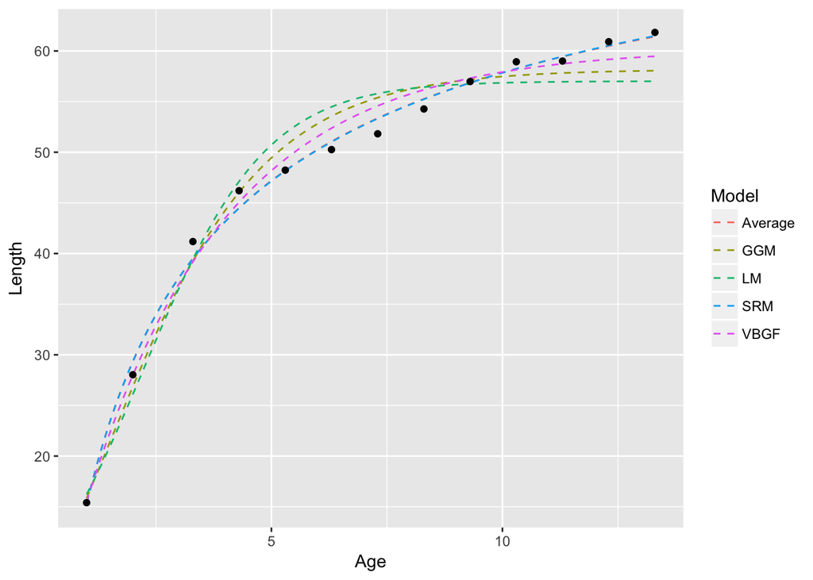

```r
dataset = data.frame(rep(seq(from = min(data[ ,1]), to = max(data[, 1]), length.out = 100), 5), c(pred_VBGF, pred_GGM, pred_LM, pred_SRM, pred_ave), c(rep("VBGF", 100), rep("GGM",100), rep("LM",100), rep("SRM",100), rep("Average", 100)))
colnames(dataset) <- c("Age", "Esimated length", "Model")

# growth curves
p <- ggplot() +
    geom_line(aes(x = dataset$Age, y = dataset$`Esimated length`, col = dataset$Model), linetype = "dashed") +
    scale_color_discrete(name = "Model") +
    labs( x = "Age", y = "Length")
p <- p + geom_point(aes(x = data[, 1], y = data[, 2]))
p # The Average curve is covered by the SRM curve.
```

Because the average curve is covered by the SRM curve, I plot this result again without SRM. (But the average model still considers the weight of SRM.)

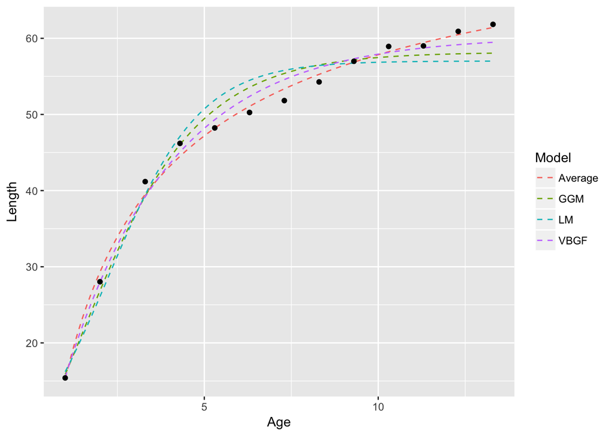

```r
dataset = data.frame(rep(seq(from = min(data[ ,1]), to = max(data[, 1]), length.out = 100), 4), c(pred_VBGF, pred_GGM, pred_LM, pred_ave), c(rep("VBGF",100), rep("GGM",100), rep("LM",100), rep("Average", 100)))
colnames(dataset) <- c("Age", "Esimated length", "Model")

# growth curves
p <- ggplot() +
    geom_line(aes(x = dataset$Age, y = dataset$`Esimated length`, col = dataset$Model), linetype = "dashed") +
    scale_color_discrete(name = "Model") +
    labs( x = "Age", y = "Length")
p <- p + geom_point(aes(x = data[, 1], y = data[, 2]))
p # In this graph, we can clearly see the Average curve.
```